# Functions

Susannah

## Quiz

1. The three elements of a function are the name of the function, the arguments of the function, and the guts of the function. *X* *Functions don’t have to have names in `R`, but the environment matters. Remember that time Hadley’s plyr masked a function in another package and you got really confused?*
2. 11
3. `1 + 2 * 3`
4. `mean(x = c(1:10, NA), na.rm = TRUE)`
5. No - the `stop` should be within the function, not the arguments to the function.
6. An infix function is a function like `+,-,/` that generally goes inbetween arguments. I don’t know what a replacement function is. *X*
7. `on.exit()`

## Functional components

1. `class` allows you to tell if an `R` object is a function. I tried to use `attributes()` to find out whether functions were primitive or not, but returned `NULL` for many functions - including functions I knew to be not primitive. Just typing the name of the function without parentheses will tell you whether the function is primitive or not. `environment(function)` returns `NULL` for all primitive functions.

```r
objs <- mget(ls("package:base"), inherits = TRUE)
nullenv <- function(func) {
    is.null(environment(func))
}
funs <- Filter(is.function, objs)
nulls <- Filter(nullenv, funs)

arg <- lapply(funs, formals) # get formals
counts <- sapply(arg, length) # count formals
maxcount <- which.max(counts) #find most args
zeros <- which(counts == 0) #no args
```

```r
  objs <- mget(ls("package:base"), inherits = TRUE)

  nullenv <- function(func) {
    # returns true if function environment is null
    is.null(environment(func))
  }

  funs <- Filter(is.function, objs)
  nulls <- Filter(nullenv, funs)
```

## Lexical scoping

1. `{r} c <- 10 c(c = c)` This code returns a vector of length one containing the number 10. The vector has a names attribute of “c.” The first `c` is the concatenate function. The second c is an attribute assignment and the third c is a variable, which was assigned to 10 in the previous line.
2. The four principles are
- name masking: names from the inner environment are used before those in the outer environment
- functions vs. variables: R can distinguish between functions and variables, but it’s confusing to *you* if you have variables and functions with the same names
- a fresh start: a new environment is created every time a function is run
- dynamic lookup: R looks for values when the function is run, of course. This isn’t a language where you have to compile things, so I don’t think there’s another way to do it…
3. 202. Evaluate inner to outer.

## EOiaFC

> Everything that exists is an object. Everything that happens is a function call. – John Chambers

## Function Arguments

Lazy evaluation means that things aren’t evaluated unless you use them. I don’t understand what closures are, *e.g.* “This is important when creating closures with lapply or a loop”

This example is confusing. Let’s work through it.

```r
add <- function(x) {
  function(y) x + y
}
adders <- lapply(1:10, add)
adders[[1]](10)
```

```
## [1] 20
```

lapply step creates a list of functions and *environments* where x is assigned according to the inputs to `lapply`.

```r
ls(environment(adders[[1]]))
```

```
## [1] "x"
```

You’d think this would lead to x being 1 in the first environment, 2 in the second environment and so on. However, because of lazy evaluation, `x` is `10` in all environments.

```r
for (i in 1:10) {
  print(get("x", pos=environment(adders[[i]])))
}
```

```
## [1] 10
## [1] 10
## [1] 10
## [1] 10
## [1] 10
## [1] 10
## [1] 10
## [1] 10
## [1] 10
## [1] 10
```

I think this has to do with promises and the way `lapply` works. `lapply` is basically a loop in C that in this case is like

`for (i in 1:10) { adders[[i]] <- add(i) }`

This loop executes in its own environment where a promise gets made for x at every iteration. At no point have we been asked to evaluate `x`, so no value has been assigned to it - just the [expression `x` and a pointer to the environment the function was called from](http://cran.r-project.org/doc/manuals/r-release/R-lang.html#Promise-objects). At the end of the `lapply` loop when the promises are due, `x` is `10`, so `x` becomes `10` in all of the `adders` environments.

If we `force(x)`, we cause the promises to come due *before* the loop ends, so that x gets assigned to the `i` in the `for` loop above instead of just the last number in the sequence.

```r
add <- function(x) {
  force(x)
  function(y) x + y
}
adders <- lapply(1:10, add)
adders[[1]](10)
```

```
## [1] 11
```

```r
for (i in 1:10) {
  print(get("x", pos=environment(adders[[i]])))
}
```

```
## [1] 1
## [1] 2
## [1] 3
## [1] 4
## [1] 5
## [1] 6
## [1] 7
## [1] 8
## [1] 9
## [1] 10
```

```r
x <- sample(c(1:10, NA), 20, replace = TRUE)
y <- runif(20, min = 0, max = 1)
cor(x, y, method = "kendall", use = "pairwise.complete.obs")
```

[output not shown]

2. The function returns 3. It illustrates default arguments and lexical scoping (name masking).
3. This function returns 100. It illustrates promises. *What is the difference between a promise and lazy evaluation? Is lazy evaluation a *type* of promise?*

# Special Calls

1.

```r
objs <- mget(ls("package:base"), inherits = TRUE)
funs <- Filter(is.function, objs)
repfun <- funs[grep(".*<-", funs)] # List of all replacement functions
nulls <- Filter(nullenv, repfun)
```

Primitive replacement functions are <<-, <-, [<-, [[<-, @<-, $<-, attr<-, attributes<-, class<-, dim<-, dimnames<-, environment<-, length<-, levels<-, names<-, oldClass<-, storage.mode<- 2. Valid names for infix functions begin and end with `%`. 3.

```r
`%|||%` <- function(x, y) {
  ( x | y) & !(x & y) # defn on wikipedia
}
x <- c(1, 2, 3)
y <- c(1, 2, 3)
(x > y) %|||%  (y < x)
```

```
## [1] FALSE FALSE FALSE
```

```r
(x == y) %|||% (x > y)
```

```
## [1] TRUE TRUE TRUE
```

4.

```r
`%uU%` <- function(x, y) {
    # find intersection of two vectors
    matches <- match(x, y, nomatch = 0)
    unique(y[matches])
}
x <- seq(2, 50, 3)
y <- seq(1, 50, 2)

all(x %uU% y == intersect(x, y))
```

```
## [1] TRUE
```

```r
`%U%` <- function(x, y) {
    # find the union of two vectors
    unique(c(x,y))
}

all(x %U% y == union(x,y))
```

```
## [1] TRUE
```

```r
`%!!%` <- function(x, y) {
    # find differences between two vectors
    matches <- match(x, y, nomatch = 0)
    unique(x[matches==0])
}

all(x %!!% y == setdiff(x, y))
```

```
## [1] TRUE
```

5.

```r
`modify_rand<-` <- function(x, value) {
  position <- floor(runif(1, max = length(x)))
  x[position] <- value
  x
}
modify_rand(x) <- 10
x
```

```
##  [1]  2  5  8 11 14 17 20 23 26 29 32 35 38 41 44 10 50
```

# Return Values

I don’t understand what `on.exit()` does when executed without an expression.

1. If `chdir` is set to `TRUE`, the `R` working directory is temporarily changed to the directory containing the source file. `in_dir()` allows you to set the directory to a new location, not necessarily the location of the source code, providing more flexibility.
2. `detach()` undoes the action of `library()`. To change the values of `options()` and `par()` do something like `options(name = value)`. Before you go changing individual name-value pairs, assign the entire list of options or parameters to some object so you’ll be able to reset it, like so:

```r
newop <- options() # assign options to a new list
options(verbose=TRUE) # talk to me R! # save a new value of an option
options(newop) # restore all options
options(newop[which(names(newop) == "verbose")]) #restore just the verbose option
```

3. My solution doesn’t work

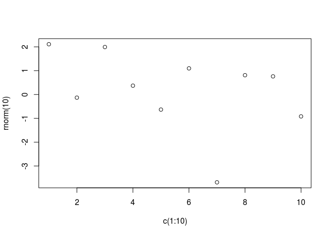

```r
make_plot <- function(file, plot_code, width=500, height=500) {
  png(file, width=width, height=height)
  plot_code
  graphics.off()
}

simpleplot <- plot(x = c(1:10), y = rnorm(10))
```

```r
#borked <- plot(x = c(1:9), y = rnorm(10))

#make_plot("~/Documents/classes/UBCadv-r/03_Functions/Functions_Susannah_plot.png", borked)
make_plot("~/Documents/classes/UBCadv-r/03_Functions/Functions_Susannah_plot.png", simpleplot)
```

4. Code is easier to understand. Output can’t be directed to a specific file with `capture.output2`. Lose access to errors. 5.

```r
capture.output <- function(..., file=NULL, append=FALSE)
{
    args <- substitute(list(...))[-1L]

    rval <- NULL; closeit <- TRUE
    if (is.null(file))
        file <- textConnection("rval", "w", local = TRUE) #if no file provided make a textConnection
    else if (is.character(file))
        file <- file(file, if(append) "a" else "w")
    else if (inherits(file, "connection")) {
if (!isOpen(file)) open(file, if(append) "a" else "w")
else closeit <- FALSE
    } else
        stop("'file' must be NULL, a character string or a connection")

    sink(file) # divert output to the file
    ## for error recovery: all output will be lost if file=NULL
    on.exit({sink(); if(closeit) close(file)})

    pf <- parent.frame()
    evalVis <- function(expr)
        withVisible(eval(expr, pf))

    for(i in seq_along(args)) {
        expr <- args[[i]]
        tmp <- switch(mode(expr),
                      "expression" = lapply(expr, evalVis),
                      "call" =, "name" = list(evalVis(expr)),
                       stop("bad argument"))
        for(item in tmp)
            if (item$visible) print(item$value)
    }
    ## we need to close the text connection before returning 'rval'
    on.exit()
    sink() # I don't get why there are multiple sinks and on.exits
    if(closeit) close(file)
    if(is.null(rval)) invisible(NULL) else rval #how could rval be anything _but_ NULL in this function?
}
```

I don’t have a good understanding of what either function is doing.